# NICAR 2020 Stats III: Logistic Regression

John Perry, Hannah Fresques

John Perry Data Journalism Team Technical Director The Atlanta Journal-Constitution John.Perry@ajc.com

Hannah Fresques Senior Data Reporter ProPublica hannah.fresques@propublica.org

[Github repository](https://github.com/fresques/nicar_logistic_regression)

With linear regression, we can learn how explanatory variables influence a continuous normally-distributed result variable. But if the result variable is binary – yes or no, male or female, passed or failed – then logistic regression is the tool of choice.

Stories that used logistic regression:

- [“Kept Out”](https://www.revealnews.org/article/how-we-identified-lending-disparities-in-federal-mortgage-data/): Reveal, 2018
  - investigation of discrimination in mortgage lending
  - (loan applicants: approved/denied)
- “A Process of Jury Elimination”: Dallas Morning News
  - investigation of discrimination in jury selection
  - jury pool: excluded/not excluded
- [“Presidential Pardons Heavily Favor Whites”](https://www.propublica.org/article/how-propublica-analyzed-pardon-data): ProPublica, 2011
  - investigation of pardons in the Bush White house
  - pardon requests: approved/denied
- [“Predict-A-Bill”](https://www.ajc.com/news/local-govt--politics/predict-bill-assesses-chances-bills-becoming-law/lCBiX6zRVWKLf23x1z4esI/): AJC
  - model to predict bill passage
  - bills: passed/did not pass
- [“Speed Traps: Who Gets a Ticket, Who Gets a Break?”](https://www.bostonglobe.com/metro/2017/07/28/old-axiom-proves-true-stay-less-than-above-speed-limit-and-you-unlikely-ticketed/HTU3lmnzuQ2hlaG1rvILFN/story.html): Boston Globe, 2017
  - investigation of discrimination in ticketing for speeding
  - people stopped for speeding: ticket/warning

## Importing and cleaning data

```r
library(readr)
library(dplyr)
library(tidyr)
library(ggplot2)
```

```r
data <- read_csv('data/boston.csv')
```

This data comes from Boston-area traffic stops. Each case in the data is someone stopped for speeding. The question is, did they get a ticket or just a warning? You can look at the data by clicking the variable name, data, in the RStudio Environment window on your right. We can also get a summary of our data with the str() function.

```r
str(data)
```

```
## Classes 'spec_tbl_df', 'tbl_df', 'tbl' and 'data.frame': 110 obs. of  18 variables:
##  $ X1      : num  1 2 3 4 5 6 7 8 9 10 ...
##  $ VAR001  : logi  NA NA NA NA NA NA ...
##  $ type    : chr  "W" "W" "W" "T" ...
##  $ citation: chr  "K0159501" "K0159502" "K0159503" "K0159504" ...
##  $ agency  : chr  "Boylston" "Boylston" "Boylston" "Boylston" ...
##  $ race    : chr  "W" "W" "W" "W" ...
##  $ sex     : chr  "M" "M" "F" "M" ...
##  $ daynight: chr  "day" "day" "day" "day" ...
##  $ day     : num  1 1 1 1 1 1 1 1 1 1 ...
##  $ descript: chr  "SPEEDING" "SPEEDING" "SPEEDING" "SPEEDING" ...
##  $ mph     : num  52 47 49 54 57 62 53 54 57 62 ...
##  $ zone    : num  35 35 35 40 45 45 35 35 45 45 ...
##  $ mphover : num  17 12 14 14 12 17 18 19 12 17 ...
##  $ mphpct  : num  49 34 40 35 27 38 51 54 27 38 ...
##  $ age     : num  26 41 50 32 48 30 30 41 60 45 ...
##  $ ticket  : num  0 0 0 1 0 0 0 0 0 0 ...
##  $ minority: num  0 0 0 0 0 0 0 0 0 0 ...
##  $ female  : num  0 0 1 0 0 1 0 0 1 1 ...
##  - attr(*, "spec")=
##   .. cols(
##   ..   X1 = col_double(),
##   ..   VAR001 = col_logical(),
##   ..   type = col_character(),
##   ..   citation = col_character(),
##   ..   agency = col_character(),
##   ..   race = col_character(),
##   ..   sex = col_character(),
##   ..   daynight = col_character(),
##   ..   day = col_double(),
##   ..   descript = col_character(),
##   ..   mph = col_double(),
##   ..   zone = col_double(),
##   ..   mphover = col_double(),
##   ..   mphpct = col_double(),
##   ..   age = col_double(),
##   ..   ticket = col_double(),
##   ..   minority = col_double(),
##   ..   female = col_double()
##   .. )
```

The data is a collection of character and number fields. Some fields - agency, citation, description - are not useful for our purpose. the useful character fields have already been converted for us to binary 1/0 values. So for convenience sake, we’ll eliminate fields that we won’t be using.

```r
data <- data %>% select(ticket, day, mph, zone, mphover, mphpct, age, minority, female)
head(data)
```

| ticket | day | mph | zone | mphover | mphpct | age | minority | female |
| --- | --- | --- | --- | --- | --- | --- | --- | --- |
| 0 | 1 | 52 | 35 | 17 | 49 | 26 | 0 | 0 |
| 0 | 1 | 47 | 35 | 12 | 34 | 41 | 0 | 0 |
| 0 | 1 | 49 | 35 | 14 | 40 | 50 | 0 | 1 |
| 1 | 1 | 54 | 40 | 14 | 35 | 32 | 0 | 0 |
| 0 | 1 | 57 | 45 | 12 | 27 | 48 | 0 | 0 |
| 0 | 1 | 62 | 45 | 17 | 38 | 30 | 0 | 1 |

We also want to make sure there’s no missing data. The is.na() function returns a TURE/FALSE matrix, TRUE if a value is missing, else FALSE. We can use the apply() function to apply the which function to the TRUE/FALSE matrix (the “2” argument means apply by column) to tell us which columns have missing values in which rows.

```r
apply(is.na(data), 2, which)
```

```
## $ticket
## integer(0)
##
## $day
## integer(0)
##
## $mph
## integer(0)
##
## $zone
## integer(0)
##
## $mphover
## integer(0)
##
## $mphpct
## integer(0)
##
## $age
## integer(0)
##
## $minority
## [1] 87
##
## $female
## [1] 87
```

With only one bad row, we can just delete it. More missing data would be a bigger problem.

```r
nrow(data)
```

```
## [1] 110
```

```r
data <- drop_na(data)
nrow(data)
```

```
## [1] 109
```

Or all at once with pipes:

```r
data <- read_csv('data/boston.csv') %>%
  select(ticket,day,mph,zone,mphover,mphpct,age,minority,female) %>%
  drop_na()

summary(data)
```

```
##      ticket            day              mph            zone
##  Min.   :0.0000   Min.   :0.0000   Min.   :42.0   Min.   :35.0
##  1st Qu.:0.0000   1st Qu.:0.0000   1st Qu.:50.0   1st Qu.:35.0
##  Median :0.0000   Median :0.0000   Median :54.0   Median :40.0
##  Mean   :0.4495   Mean   :0.4771   Mean   :54.6   Mean   :39.4
##  3rd Qu.:1.0000   3rd Qu.:1.0000   3rd Qu.:58.0   3rd Qu.:45.0
##  Max.   :1.0000   Max.   :1.0000   Max.   :68.0   Max.   :50.0
##     mphover          mphpct           age           minority
##  Min.   : 7.00   Min.   :20.00   Min.   :17.00   Min.   :0.0000
##  1st Qu.:13.00   1st Qu.:33.00   1st Qu.:25.00   1st Qu.:0.0000
##  Median :15.00   Median :38.00   Median :34.00   Median :0.0000
##  Mean   :15.19   Mean   :39.19   Mean   :36.01   Mean   :0.1651
##  3rd Qu.:17.00   3rd Qu.:43.00   3rd Qu.:46.00   3rd Qu.:0.0000
##  Max.   :25.00   Max.   :71.00   Max.   :74.00   Max.   :1.0000
##      female
##  Min.   :0.000
##  1st Qu.:0.000
##  Median :0.000
##  Mean   :0.422
##  3rd Qu.:1.000
##  Max.   :1.000
```

One more thing to check: is our response variable split roughly equally between yes and no. If one greatly outnumbers the other, then our results will be biased.

```r
data %>% count(ticket)
```

| ticket | n |
| --- | --- |
| 0 | 60 |
| 1 | 49 |

Close enough!

## Linear regression with a dummy variable:

With linear regression, you can use a binary explanatory/independent variable. As an example, we can look at how minority – binary, 0 or 1, variable – interacts with speed zone. But first, lets do that the most simple way using grouped means:

```r
data %>%
  group_by(minority) %>%
  summarise(freq=n(),mean=mean(zone)) %>%
  round(., 2)
```

| minority | freq | mean |
| --- | --- | --- |
| 0 | 91 | 39.84 |
| 1 | 18 | 37.22 |

And we can do essentially the same thing with linear regression:

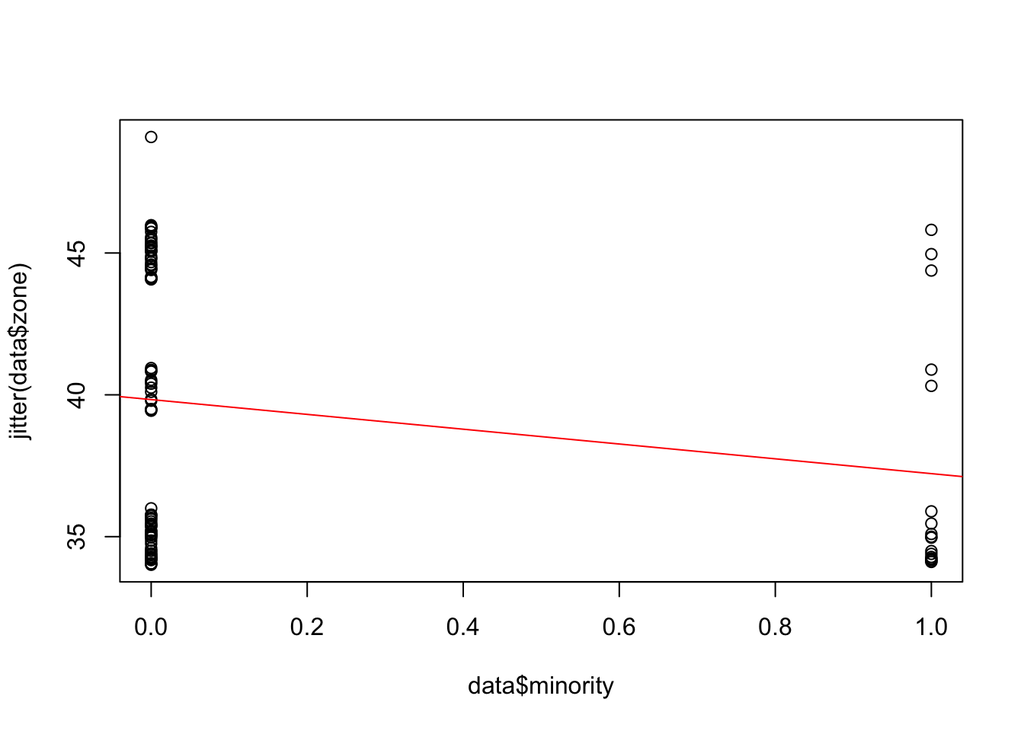

```r
m.binary_independent <- lm(zone ~ minority, data=data)
plot(data$minority, jitter(data$zone))
abline(m.binary_independent, col="red")
```

```r
summary(m.binary_independent)
```

```
##
## Call:
## lm(formula = zone ~ minority, data = data)
##
## Residuals:
##     Min      1Q  Median      3Q     Max
## -4.8352 -4.8352  0.1648  5.1648 10.1648
##
## Coefficients:
##             Estimate Std. Error t value Pr(>|t|)
## (Intercept)   39.835      0.479  83.171   <2e-16 ***
## minority      -2.613      1.179  -2.217   0.0287 *
## ---
## Signif. codes:  0 '***' 0.001 '**' 0.01 '*' 0.05 '.' 0.1 ' ' 1
##
## Residual standard error: 4.569 on 107 degrees of freedom
## Multiple R-squared:  0.04392,    Adjusted R-squared:  0.03498
## F-statistic: 4.915 on 1 and 107 DF,  p-value: 0.02874
```

## Linear regression and binary result variables?

We know that we can use a binary independent variable in a linear regression model – this is called a dummy variable. But what if our result variable is binary?

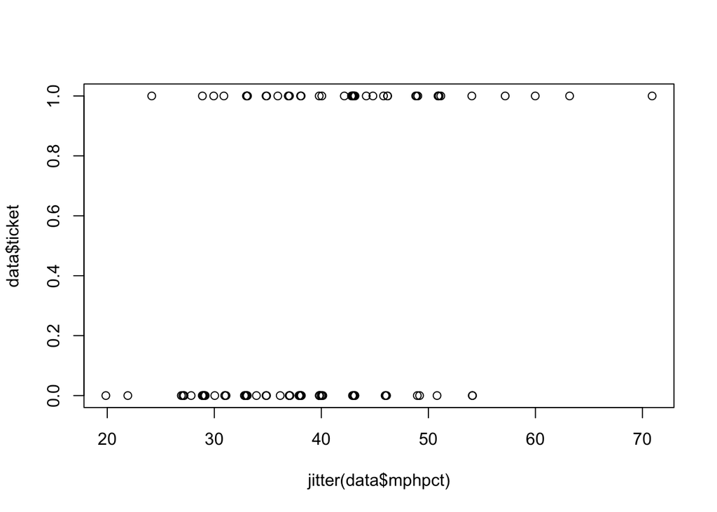

```r
plot(jitter(data$mphpct), data$ticket)
```

```r
m.linear <- lm(ticket ~ mphpct, data=data)
summary(m.linear)
```

```
##
## Call:
## lm(formula = ticket ~ mphpct, data = data)
##
## Residuals:
##     Min      1Q  Median      3Q     Max
## -0.7426 -0.4259 -0.2082  0.4751  0.8511
##
## Coefficients:
##              Estimate Std. Error t value Pr(>|t|)
## (Intercept) -0.326162   0.206634  -1.578 0.117414
## mphpct       0.019792   0.005145   3.847 0.000204 ***
## ---
## Signif. codes:  0 '***' 0.001 '**' 0.01 '*' 0.05 '.' 0.1 ' ' 1
##
## Residual standard error: 0.4706 on 107 degrees of freedom
## Multiple R-squared:  0.1215, Adjusted R-squared:  0.1133
## F-statistic:  14.8 on 1 and 107 DF,  p-value: 0.0002039
```

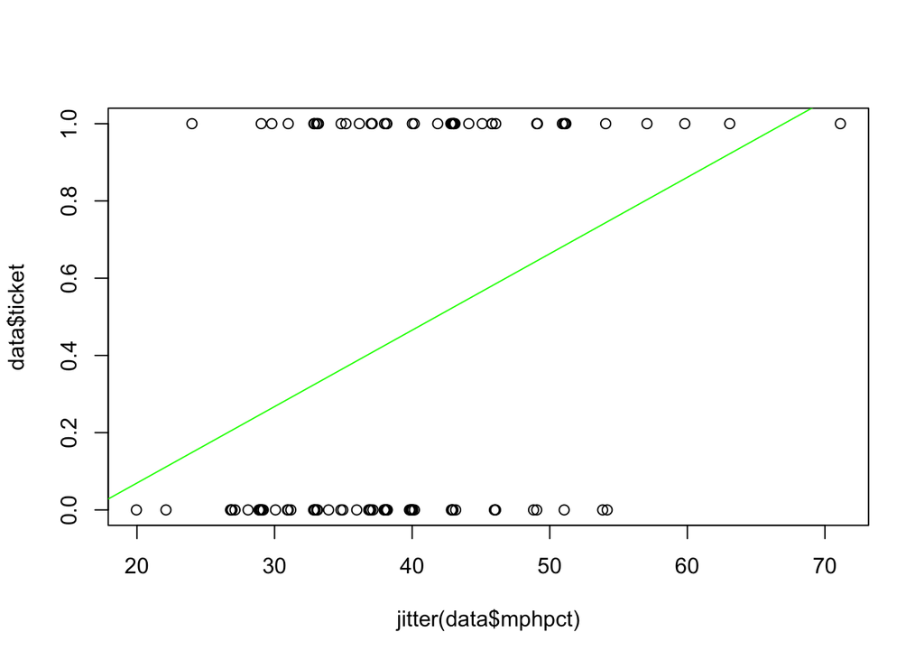

```r
plot(jitter(data$mphpct), data$ticket)
abline(m.linear, col='green')
```

Linear regression function gave us a result, but what does it mean? Values on the regression line represent the best estimate of the mean y value for a certain x value: mean(y) = sum of all the y’s/count of cases for a specific x. Since y is binary, either 1 or 0, then that translates to tickets / stops, which is how we define probability. So the predicted value from our linear regression predicted value is the probability of getting a ticket when driving x percent over the speed limit.

## But there’s a problem

```r
print(m.linear)
```

```
##
## Call:
## lm(formula = ticket ~ mphpct, data = data)
##
## Coefficients:
## (Intercept)       mphpct
##    -0.32616      0.01979
```

if we plug 71 percent – our largest mphpct value – into the linear equation taken from our regression coefficients, then the probability of getting a tick for driving 71 percent above the speed limit is -0.326162 + 0.019792 * 71

```r
-0.326162 + 0.019792 * 71
```

```
## [1] 1.07907
```

Probabilities above 1 are impossible. A linear function - a function that gives us impossible values - won’t work. We need a function that only gives us values between 1 and 0:

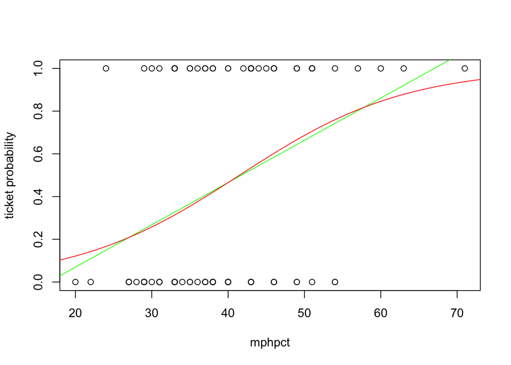

```r
# recreate our previous plot
plot(data$mphpct, data$ticket, xlab="mphpct", ylab="ticket probability")
m.linear <- lm(ticket ~ mphpct, data=data)
abline(m.linear, col='green')

# add logit function plot

# create a logistic regression model:
m.logistic <- glm(ticket ~ mphpct, data=data, family='binomial')

# create a list of 100 mphpct values between 0 and 5 more than our highest value:
plotData <- data.frame(mphpct=seq(0,max(data$mphpct) + 5, len=100))

# Us our model to add the predicted probability of getting a ticket for those mphpct values:
plotData$ticket = predict(m.logistic, newdata=plotData, type='response')

# plot it:
lines(ticket~mphpct, plotData, col='red')
```

But instead of $p(y)=\beta _{0}+\beta _{1}x$, we now have:

$$p(y)={\frac {e^{(\beta _{0}+\beta _{1}x)}}{e^{(\beta _{0}+\beta _{1}x)}+1}}$$

How do we describe this relationship in our story?

## A digression: Probability and Odds

- Probability = tickets / all traffic stops
- Odds = tickets / warning
  - Also: p(tickets) / p(warning)
  - Also: p(tickets) / 1 - p(tickets)
- Probability of pulling a diamond from a deck of cards:
  - 13 / 52 = 0.25 (25%)
- Odds of pulling a diamond from a deck of cards:
  - 13 / 39 = 1/3 = 0.33
- or as a probability ratio:
  - 0.25 / (1 - 0.25) = 0.33

O = p / (1-p)

p = O / (O + 1)

Probability can be any value from 0 to 1. Which is why we can’t use linear regression to predict it!

Odds can be any value from 0 and infinity. If the odds are in your favor - greater than 1:1 - the odds are between 1 and infinity. If the odds are against you - less than 1:1 - then the odds are between 0 and 1.

Odds aren’t a good dependent variable for linear regression either, because predicted values from linear regression can be -infinity to +infinity.

BUT! log(Odds) gives you any values from -infinity to +infinity. Some examples:

log(3 to 1) = log(3) = 1.1

log(1 to 3) = log(0.3333) = -1.1

## Log(Odds): the Logit Function

Our weird friend from before:

$$p(y)={\frac {e^{(\beta _{0}+\beta _{1}x)}}{e^{(\beta _{0}+\beta _{1}x)}+1}}$$

Can also be written as: (do the algebra if you want to check)

$${\frac {p(y)}{1-p(y)}}={e^{(\beta _{0}+\beta _{1}x)}}$$

which is the same as

$$Odds(y)={e^{(\beta _{0}+\beta _{1}x)}}$$

If we take the log of both sides, we get:

$$log(Odds(y))=\beta _{0}+\beta _{1}x$$
This is the logit function. TADA.

If we convert the probabilities of getting a ticket to the log of the odds of getting a ticket, we’re back to a line:

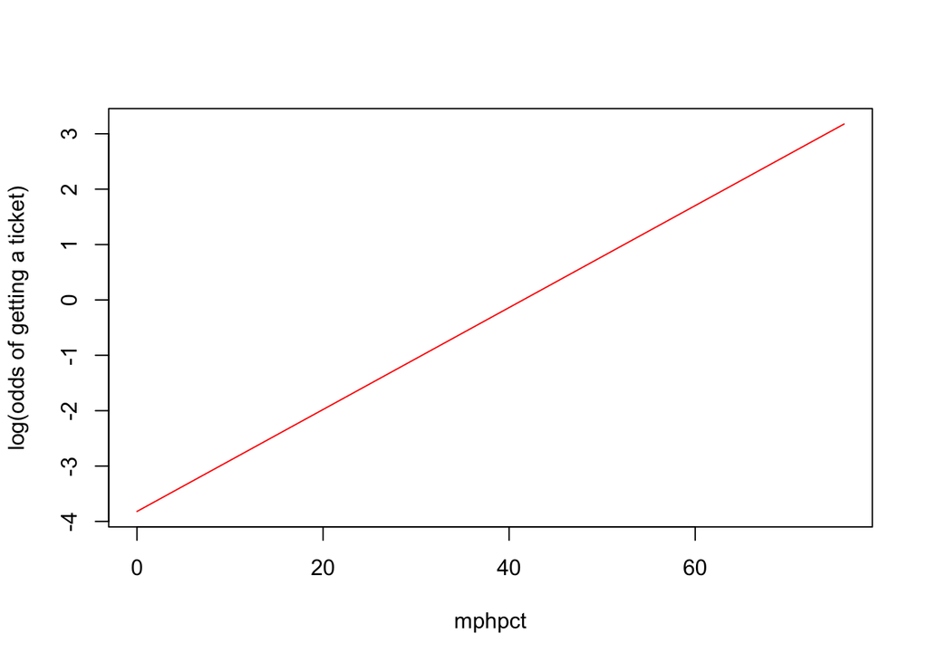

```r
# add log odds values to our plot data
# (remember that on plotData, ticket is continuous 0-1)
plotData <- plotData %>%
  mutate(
    ticketLogOdds = log(ticket / (1 - ticket))
    )

# plot the log odds of getting a ticket as predicted by mphpct
plot(plotData$mphpct, plotData$ticketLogOdds, type="l", col="red", ylab="log(odds of getting a ticket)", xlab="mphpct")
```

A Generalized Linear Model (GLM) is $linkFunction(y)=\beta _{0}+\beta _{1}x$

In logistic regression, the link function is $log({\frac {p}{1-p}})$, or $log(Odds)$

## Analyzing the data … finally

Manually calculating the probability and odds of getting a ticket, or not.

```r
# (remember that on data, ticket is binary 0/1)
data %>%
  group_by(ticket) %>%
  summarise(
    freq=n(),
    prob=(n()/nrow(.)),
    odds=prob/(1-prob),
    logodds=log(odds)
  ) %>%
  round(., 4)
```

| ticket | freq | prob | odds | logodds |
| --- | --- | --- | --- | --- |
| 0 | 60 | 0.5505 | 1.2245 | 0.2025 |
| 1 | 49 | 0.4495 | 0.8167 | -0.2025 |

## The Null Model: should match simple calculations above

```r
m.null <- glm(ticket ~ 1, data=data, family='binomial')
summary(m.null)
```

```
##
## Call:
## glm(formula = ticket ~ 1, family = "binomial", data = data)
##
## Deviance Residuals:
##    Min      1Q  Median      3Q     Max
## -1.093  -1.093  -1.093   1.265   1.265
##
## Coefficients:
##             Estimate Std. Error z value Pr(>|z|)
## (Intercept)  -0.2025     0.1925  -1.052    0.293
##
## (Dispersion parameter for binomial family taken to be 1)
##
##     Null deviance: 149.99  on 108  degrees of freedom
## Residual deviance: 149.99  on 108  degrees of freedom
## AIC: 151.99
##
## Number of Fisher Scoring iterations: 3
```

Exponent of the coefficient

```r
exp(coef(m.null))
```

```
## (Intercept)
##   0.8166667
```

## A more interesting model: ticket ~ mphpct

```r
m.mphpct <- glm(ticket ~ mphpct, data=data, family='binomial')
summary(m.mphpct)
```

```
##
## Call:
## glm(formula = ticket ~ mphpct, family = "binomial", data = data)
##
## Deviance Residuals:
##     Min       1Q   Median       3Q      Max
## -1.6886  -1.0441  -0.6837   1.1193   1.8936
##
## Coefficients:
##             Estimate Std. Error z value Pr(>|z|)
## (Intercept) -3.81981    1.08319  -3.526 0.000421 ***
## mphpct       0.09205    0.02709   3.398 0.000678 ***
## ---
## Signif. codes:  0 '***' 0.001 '**' 0.01 '*' 0.05 '.' 0.1 ' ' 1
##
## (Dispersion parameter for binomial family taken to be 1)
##
##     Null deviance: 149.99  on 108  degrees of freedom
## Residual deviance: 135.85  on 107  degrees of freedom
## AIC: 139.85
##
## Number of Fisher Scoring iterations: 4
```

The coefficient for mphpct is 0.09205, which tells us (just like in linear regression) that a 1 percentage point increase in mphpct means an increase in the log of the odds of getting a ticket of about 0.09:

log odds at (mphpct + 1) = (log odds at mphpct) + 0.09

If you want to put this relationship in terms readers will understand, like odds, we take the exponent of the coefficient. But by taking the exponent, we change the addition to multiplication:

```r
exp(coef(m.mphpct))
```

```
## (Intercept)      mphpct
##  0.02193191  1.09641619
```

odds at (mphpct + 1) = (odds at mphpct) * 1.09

Or

For every one percentage point increase in speed over the limit, you increase your odds of getting a ticket by 9 percent.

## What if the explanatory/independent variable is binary?

```r
m.minority <- glm(ticket ~ minority, data=data, family='binomial')
summary(m.minority)
```

```
##
## Call:
## glm(formula = ticket ~ minority, family = "binomial", data = data)
##
## Deviance Residuals:
##     Min       1Q   Median       3Q      Max
## -1.8930  -0.9673  -0.9673   1.4032   1.4032
##
## Coefficients:
##             Estimate Std. Error z value Pr(>|z|)
## (Intercept)  -0.5167     0.2167  -2.384  0.01711 *
## minority      2.1261     0.6685   3.180  0.00147 **
## ---
## Signif. codes:  0 '***' 0.001 '**' 0.01 '*' 0.05 '.' 0.1 ' ' 1
##
## (Dispersion parameter for binomial family taken to be 1)
##
##     Null deviance: 149.99  on 108  degrees of freedom
## Residual deviance: 136.50  on 107  degrees of freedom
## AIC: 140.5
##
## Number of Fisher Scoring iterations: 4
```

Intercept represents the estimate for non-minorities. The minority coefficient is the log of the odds ratio: minority odds / non-minority odds.

```r
exp(coef(m.minority))
```

```
## (Intercept)    minority
##   0.5964912   8.3823529
```

Odds of a minority driver getting a ticket are 8-times greater than for a white driver.

```r
# (remember that on data, ticket is binary 0/1)
data %>%
  group_by(minority) %>%
  summarise(
    n=n(),
    n_tickets=sum(ticket),
    prob=n_tickets/n,
    odds=prob/(1-prob),
    logodds=log(odds)
  ) %>%
  round(., 4)
```

| minority | n | n_tickets | prob | odds | logodds |
| --- | --- | --- | --- | --- | --- |
| 0 | 91 | 34 | 0.3736 | 0.5965 | -0.5167 |
| 1 | 18 | 15 | 0.8333 | 5.0000 | 1.6094 |

The odds ratio is 5/0.5965 = 8.38223, which matches the coefficent above.

## R-squared … sorta

McFadden’s Pseudo R-squared

```r
ll.null <- m.minority$null.deviance / -2
ll.proposed <- m.minority$deviance / -2
(ll.null - ll.proposed) / ll.null
```

```
## [1] 0.08998906
```

p-value for R-squared:

```r
1 - pchisq(2*(ll.proposed - ll.null), df=(length(m.minority$coefficients) - 1))
```

```
## [1] 0.0002388397
```

## Let’s make it multivariate

```r
m.best_predictions <- glm(ticket ~ minority + mphover + female + age, data=data, family=binomial)
summary(m.best_predictions)
```

```
##
## Call:
## glm(formula = ticket ~ minority + mphover + female + age, family = binomial,
##     data = data)
##
## Deviance Residuals:
##     Min       1Q   Median       3Q      Max
## -1.7624  -0.8869  -0.4835   0.8119   2.0755
##
## Coefficients:
##             Estimate Std. Error z value Pr(>|z|)
## (Intercept) -3.60636    1.58908  -2.269  0.02324 *
## minority     2.03457    0.69688   2.920  0.00351 **
## mphover      0.28757    0.09498   3.028  0.00246 **
## female      -0.76965    0.45999  -1.673  0.09429 .
## age         -0.02737    0.01812  -1.510  0.13100
## ---
## Signif. codes:  0 '***' 0.001 '**' 0.01 '*' 0.05 '.' 0.1 ' ' 1
##
## (Dispersion parameter for binomial family taken to be 1)
##
##     Null deviance: 149.99  on 108  degrees of freedom
## Residual deviance: 119.22  on 104  degrees of freedom
## AIC: 129.22
##
## Number of Fisher Scoring iterations: 4
```

McFadden’s Pseudo R-squared

```r
ll.null <- m.best_predictions$null.deviance/-2
ll.proposed <- m.best_predictions$deviance/-2
(ll.null - ll.proposed) / ll.null
```

```
## [1] 0.2051807
```

p-value for R-squared:

```r
1 - pchisq(2*(ll.proposed - ll.null), df=(length(m.best_predictions$coefficients) - 1))
```

```
## [1] 3.40113e-06
```

Visualize our predictions:

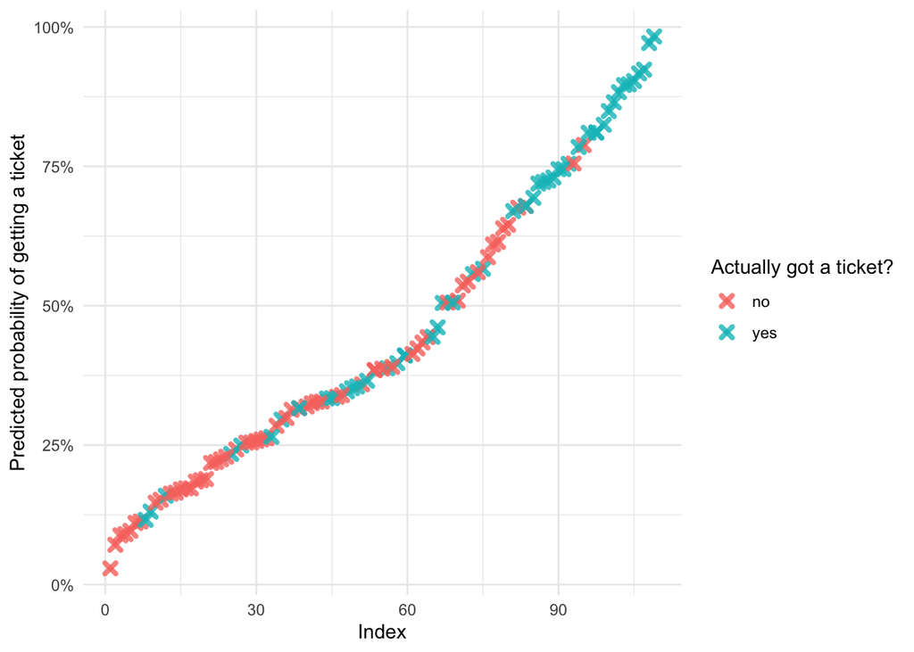

```r
predicted.data <- data.frame(
  probability = m.best_predictions$fitted.values,
  ticket=data$ticket
  ) %>%
  mutate(
    rank=rank(probability),
    ticket_desc=ifelse(ticket==1,'yes','no')
  )

ggplot(data=predicted.data, aes(x=rank, y=probability)) +
  geom_point(aes(color=ticket_desc), alpha=0.8, shape=4, stroke=2) +
  scale_color_discrete(name="Actually got a ticket?") +
  scale_y_continuous(labels = scales::percent) +
  xlab("Index") +
  ylab("Predicted probability of getting a ticket") +
  theme_minimal()
```